# peak_call_per_celltype

## Peak calling per cell type

The peak calling workflow for each cell type consists of four main steps:

1. **Prepare Tn5 Insertion Files**: Generate a Tn5 insertion file for each cell type.
2. **Peak Calling with MACS2**: Use the MACS2 tool to call peaks per cell type.
3. **Filter and Aggregate Peaks**: Filter the called peaks for each cell type and combine them to create a final peak file.
4. **Generate BIGWIG Files**: Create BIGWIG files for browser visualization.

Users can adjust the p-value or q-value in MACS2 to obtain different peak sets based on desired cutoff thresholds. During the filtering step, users can apply a range of FDR cutoffs to generate multiple peak files, which can be further examined in a browser to determine the most suitable peak set.

**Inputs** (Required):  
1. **-script_dir** (a script directory downloaded from GitHub: Socrates2/utils/input_other_required_scripts_dir)  
2. **-soc_obj** (The *.atac.soc.qs2 object obtained from the [6. Annotate cell identity](http://htmlpreview.github.io/?https://github.com/yanhaidong1/Socrates2/blob/main/vignettes/annotate_cell_identity.html) step)  
3. **-tn5_fl** (The **opt_tn5_mq10_sorted.bed** obtained from [4. Prepare gene accessibility](http://htmlpreview.github.io/?https://github.com/yanhaidong1/Socrates2/blob/main/vignettes/prepare_gene_accessibility.html) step which records the coordinates of each Tn5 insertions per cell)  
4. **-meta_fl** (Optional if `-soc_obj` is used. A final meta file with cell identities being annotated. If users have already executed Option 5: Generate the final UMAP plot with labeled cell identities under [6. Annotate cell identity](http://htmlpreview.github.io/?https://github.com/yanhaidong1/Socrates2/blob/main/vignettes/annotate_cell_identity.html), the required input file is *.annotated_cell_identity.meta.txt, generated in Option 5.)  
5. **-Ggff_fl** (A gene GFF3 file used to extract the exon when performing peak permutation)  
6. **-Gmfai_fl** (A genome fai index file built up by samtools faidx)  
7. **-g_size** (Provide an effective genome size)  
8. **-o output_dir** (mkdir output_dir)

**Optional parameters:**  
1. **-s1_open_tn5 yes|no** (Run the step 01 to prepare the tn5 file per cell type. Default: yes)  
2. **-s2_open_peak yes|no** (Run the step 02 to call peaks per cell type. Default: yes)  
3. **-s3_open_filter yes|no** (Run the step 03 to filter peaks from all the peak calling. Default: yes)  
4. **-s4_open_bigwig yes|no** (Run the step 04 to obtain the bigwig file per cell type. Default: yes)  
5. **-open_build_object yes|no** (Run saving final peak BED file to an object. Default: no)  
6. **-final_peak_fl** (Provide the final peak BED file if you have selected an appropriate peak file from `s3_open_filter_peak_final_dir/opt_final.*Peaks.fx.sorted.bed`.)  
7. **-organelle_chr_name** (Specify the names of organelle chromosomes in the genome FASTA file. Peaks located on these chromosomes will be excluded from the final peak file. Multiple names should be separated by commas. For example: `-organelle_chr_name` ChrPt,ChrMt.)  
8. **-core** (Set cores we will use for the parallele analysis. Default: 1)  
9. **-ct_colnm** (A column name in the metadata file specifying the cell identity. If users have already executed Option 5: Generate the final UMAP plot with labeled cell identities under [6. Annotate cell identity](http://htmlpreview.github.io/?https://github.com/yanhaidong1/Socrates2/blob/main/vignettes/annotate_cell_identity.html), the value should be `-ct_colnm cell_identity`.)  
10. **-umapp_fl** (Provide the unmappable file that will help build the imputated region. Default: None)  
11. **-p_or_q** (Provide to use p value or q value using MACS2. Default: pval). **-cutoff** (Provide an exact cutoff for either pvalue or qvalue. Default: 0.05)  
12. **-SLOCAL** (Provide a parameter setting of SLOCAL within MACS2 to adjust bp count for small local region. Default: 75)  
13. **-LLOCAL** (Provide a parameter setting of SLOCAL within MACS2 to adjust bp count for large local region. Default: 500)  
14. **-max_gap** (Provide a parameter setting of max_gap within MACS2 to decide whether the nearby peaks will be merged. If the distance between two nearby peaks is smaller than `max-gap` then they will be merged as one. Default: 10)  
15. **-FDR** (Provide a FDR string to return all the peak files with all defined FDR values with performing peak filtration. Default: 0.05,0.01,0,005,0.001)

**Outputs**  
1. s3_open_filter_peak_final_dir/**opt_final.*Peaks.fx.sorted.bed**  
2. s4_open_bigwig_build_final_dir/store_store_final_bw_dir/*.bw

**Running**:

```bash
python Socrates2/utils/cell_type_peak_calling.py
-script_dir Socrates2/utils/input_other_required_scripts_dir
-o output_dir
-tn5_fl opt_tn5_mq10_sorted.bed
-soc_obj /Path/to/*.atac.soc.qs2
-Ggff_fl gene.gff3
-Gmfai_fl genome.fai
-g_size 3e8 (Users need to adjust this value to match their own effect genome size)
```

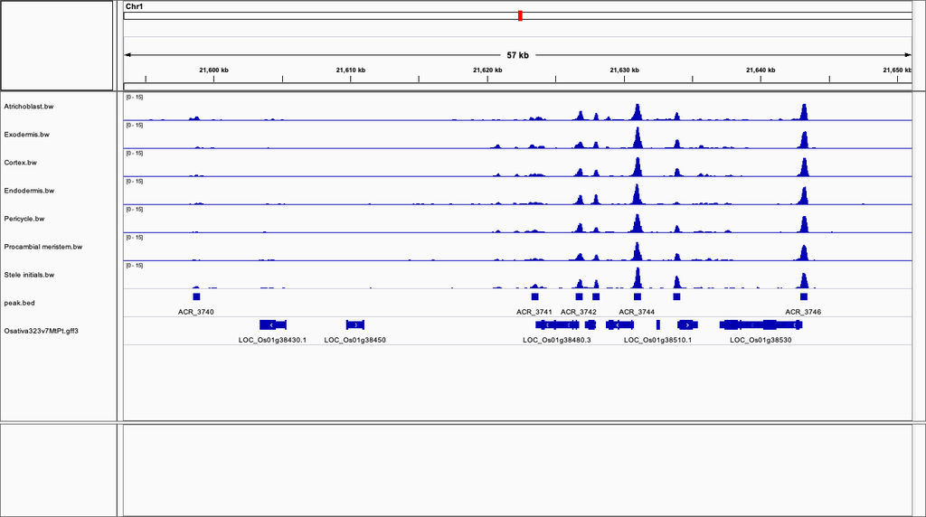

Figure 1: example of peak calling shown using IGV presenter

### Save final peak to an output object

```bash
python Socrates2/utils/cell_type_peak_calling.py
-script_dir Socrates2/utils/input_other_required_scripts_dir
-o output_dir
-open_build_object yes
-soc_obj /Path/to/*.atac.soc.qs2
-final_peak_fl /Path/to/Peak.bed
```

**Outputs**  
1. *.atac.soc.qs2